# lab-10: Distances and the Border Zone

# Question 2:

Here we will focus on calculating the distance of each USA city to (1) the national border (2) the nearest state border (3) the Mexican border and (4) the Canadian border. You will need to manipulate you existing spatial geometries to do this using either st_union or st_combine depending on the situation. In all cases, since we are after distances to borders, we will need to cast (st_cast) our MULTIPPOLYGON geometries to MULTILINESTRING geometries. To perform these distance calculations we will use st_distance().

# 2.1 Distance to USA Border (coastline or national) (km)

For 2.2 we are interested in calculating the distance of each USA city to the USA border (coastline or national border). To do this we need all states to act as single unit. Convert the USA state boundaries to a MULTILINESTRING geometry in which the state boundaries are resolved. Please do this starting with the states object and NOT with a filtered country object. In addition to storing this distance data as part of the cities data.frame, produce a table (flextable) documenting the five cities farthest from a state border. Include only the city name, state, and distance.

```r
# Union all state boundaries into a single polygon
usa_union <- st_union(states_eqdc)

# Convert to a MULTILINESTRING for border geometry
usa_border <- st_cast(usa_union, "MULTILINESTRING")

#Calculate distance from each city to national border (in kilometers)
dist_to_border_m <- st_distance(cities_eqdc, usa_border)
cities_eqdc$dist_to_border_km <- as.numeric(dist_to_border_m) / 1000 #convert m to km

# Create a summary table of the 5 most inland cities
top5_far_cities <- cities_eqdc %>%
  arrange(desc(dist_to_border_km)) %>%
  slice(1:5) %>%
  select(city, state_id, dist_to_border_km)

flextable(top5_far_cities)
```

| city | state_id | dist_to_border_km | geometry |
| --- | --- | --- | --- |
| Attu Station | AK | 4,118.416 | [[XY]] |
| Eareckson Station | AK | 4,060.616 | [[XY]] |
| Kekaha | HI | 3,762.144 | [[XY]] |
| Kaumakani | HI | 3,758.751 | [[XY]] |
| Pakala Village | HI | 3,758.405 | [[XY]] |

# 2.2 - Distance to States (km)

For 2.1 we are interested in calculating the distance of each city to the nearest state boundary. To do this we need all states to act as single unit. Convert the USA state boundaries to a MULTILINESTRING geometry in which the state boundaries are preserved (not resolved). In addition to storing this distance data as part of the cities data.frame, produce a table (flextable) documenting the five cities farthest from a state border. Include only the city name, state, and distance.

```r
#Use st_combine() instead of st_union() (so borders between states remain),
#Convert the result to MULTILINESTRING to represent all state boundaries,
#Then compute distances from cities to those lines.

# Combine geometries without resolving internal boundaries
state_borders <- states_eqdc %>%
  st_combine() %>%
st_cast("MULTILINESTRING") #represents all state lines, including interior borders.


#Calculate distance from each city to the nearest state boundary
dist_to_state_border_m <- st_distance(cities_eqdc, state_borders)
cities_eqdc$dist_to_state_km <- as.numeric(dist_to_state_border_m) / 1000 #m to km

#Identify the 5 cities farthest from any state boundary
top5_far_from_state <- cities_eqdc %>%
  arrange(desc(dist_to_state_km)) %>%
  slice(1:5) %>%
  select(city, state_id, dist_to_state_km)

flextable(top5_far_from_state)
```

| city | state_id | dist_to_state_km | geometry |
| --- | --- | --- | --- |
| Attu Station | AK | 4,118.416 | [[XY]] |
| Eareckson Station | AK | 4,060.616 | [[XY]] |
| Kekaha | HI | 3,762.144 | [[XY]] |
| Kaumakani | HI | 3,758.751 | [[XY]] |
| Pakala Village | HI | 3,758.405 | [[XY]] |

# 2.3 - Distance to Mexico (km)

For 2.3 we are interested in calculating the distance of each city to the Mexican border. To do this we need to isolate Mexico from the country objects. In addition to storing this data as part of the cities data.frame, produce a table (flextable) documenting the five cities farthest from a state border. Include only the city name, state, and distance.

```r
# using existing countries_eqdc object, which includes USA, Canada, and Mexico, all projected in EQDC.

# Filter for Mexico only
mexico <- countries_eqdc %>%
  filter(sovereignt == "Mexico")  # use column name sovereignt == "Mexico"

# Convert Mexico to a border line
mexico_border <- mexico %>%
  st_union() %>%
  st_cast("MULTILINESTRING") #MULTILINESTRING to represent the border outline of Mexico

# Calculate distances from cities to Mexico
dist_to_mexico_m <- st_distance(cities_eqdc, mexico_border)
cities_eqdc$dist_to_mexico_km <- as.numeric(dist_to_mexico_m) / 1000 #m to km

# Create a table of the 5 cities farthest from the Mexican border
top5_far_from_mexico <- cities_eqdc %>%
  arrange(desc(dist_to_mexico_km)) %>%
  slice(1:5) %>%
  select(city, state_id, dist_to_mexico_km)

flextable(top5_far_from_mexico)
```

| city | state_id | dist_to_mexico_km | geometry |
| --- | --- | --- | --- |
| Attu Station | AK | 5,640.179 | [[XY]] |
| Eareckson Station | AK | 5,576.325 | [[XY]] |
| Point Hope | AK | 5,061.411 | [[XY]] |
| Gambell | AK | 5,026.623 | [[XY]] |
| Point Lay | AK | 5,016.127 | [[XY]] |

# 2.4 Distance to Canada (km)

For 2.4 we are interested in calculating the distance of each city to the Canadian border. To do this we need to isolate Canada from the country objects. In addition to storing this data as part of the cities data.frame, produce a table (flextable) documenting the five cities farthest from a state border. Include only the city name, state, and distance.

```r
# Filter for Canada, Convert Canada polygon to border lines
canada_border <- countries_eqdc %>%
  filter(name == "Canada") %>%
  st_union() %>%
  st_cast("MULTILINESTRING")

#Compute distance from each city to the Canadian border
cities_eqdc$dist_to_canada_km <- st_distance(cities_eqdc, canada_border) %>%
  as.numeric() / 1000 #m to km

# Create a table: 5 cities farthest from the Canadian border
top5_far_from_canada <- cities_eqdc %>%
  arrange(desc(dist_to_canada_km)) %>%
  slice(1:5) %>%
  select(city, state_id, dist_to_canada_km)

flextable(top5_far_from_canada)
```

| city | state_id | dist_to_canada_km | geometry |
| --- | --- | --- | --- |
| Hawaiian Ocean View | HI | 4,151.650 | [[XY]] |
| Discovery Harbour | HI | 4,149.978 | [[XY]] |
| Waiohinu | HI | 4,146.501 | [[XY]] |
| Naalehu | HI | 4,144.805 | [[XY]] |
| Pahala | HI | 4,127.362 | [[XY]] |

# Question 3:

In this section we will focus on visualizing the distance data you calculated above. You will be using ggplot to make your maps, ggrepl to label significant features, and gghighlight to emphasize important criteria.

# 3.1 Data

Show the 3 continents, CONUS outline, state boundaries, and 10 largest USA cities (by population) on a single map

Use geom_sf to plot your layers Use lty to change the line type and size to change line width Use ggrepel::geom_label_repel to label your cities

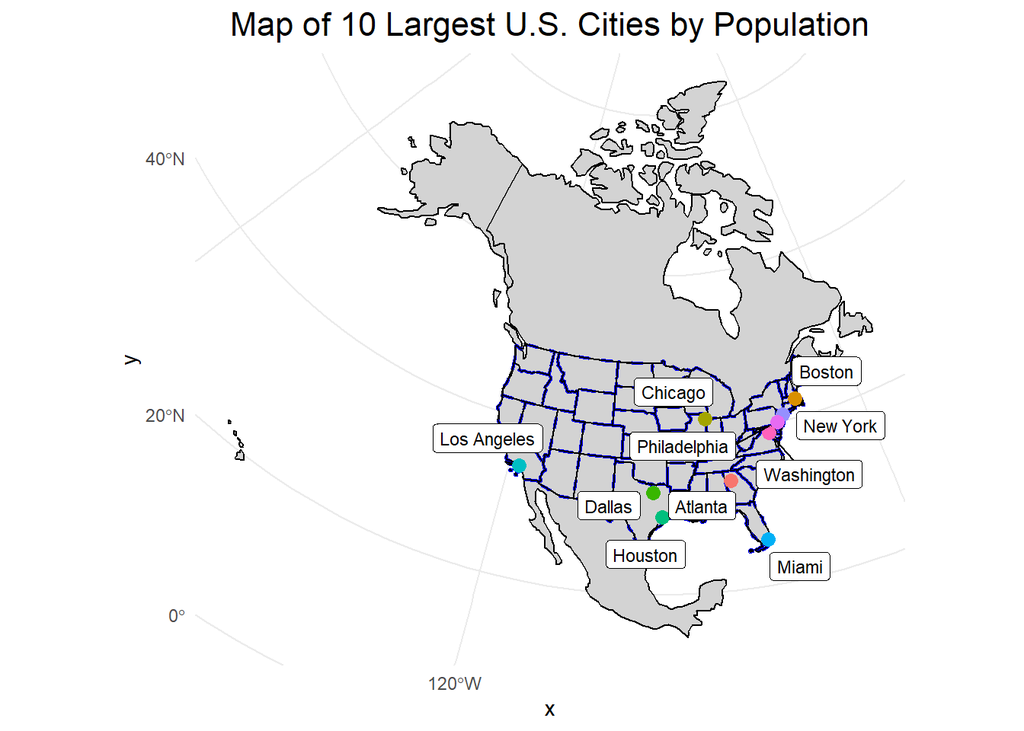

```r
# Filter the 10 Largest U.S. Cities by Population
# Filter the 10 largest cities by population
top_10_cities <- cities_eqdc %>%
  arrange(desc(population)) %>%
  slice(1:10)

 # Prepare Spatial Layers for Plotting
# Continents: already have countries_eqdc for USA, Canada, and Mexico.
# CONUS Outline: This is the outline of the contiguous United States.
# State Boundaries: The states_eqdc layer used earlier.
# countries_eqdc, states_eqdc, and cities_eqdc

# Add coordinates to your top_10_cities data frame before using it in geom_label_repel():
top_10_cities_coords <- top_10_cities %>%
  mutate(
    coords = st_coordinates(geometry),
    x = coords[, 1],
    y = coords[, 2]
  )

#pass x and y to geom_label_repel():



# Create the plot with all the layers
ggplot() +
  # Plot continents (USA, Canada, Mexico)
  geom_sf(data = countries_eqdc, fill = "lightgray", color = "black", lwd = 0.5) +

  # Plot CONUS outline (only USA). lty= line type, lwd= line width
  geom_sf(data = states_eqdc, fill = NA, color = "blue", lty = 2, lwd = 0.8) +

  # Plot state boundaries
  geom_sf(data = states_eqdc, fill = NA, color = "black", lty = 1, lwd = 0.5) +

  # Plot the cities (top 10 largest cities by population)
  geom_sf(data = top_10_cities, aes(color = city), size = 3) +

  # Use ggrepel to label the cities. avoids overlapping, but you can adjust padding with box.padding and point.padding
  geom_label_repel(data = top_10_cities_coords, aes(x= x, y=y, label = city),
                   box.padding = 0.35, point.padding = 0.5,
                   segment.color = "black", size = 3) +

  # Customize the theme
  theme_minimal() +

  # Add a title
  ggtitle("Map of 10 Largest U.S. Cities by Population") +

  # Adjusting the theme
  theme(
    plot.title = element_text(hjust = 0.5, size = 16),
    legend.position = "none"  # Hide legend
  )
```

# 3.2 City Distance from the Border

Create a map that colors USA cities by their distance from the national border. In addition, re-draw and label the 5 cities that are farthest from the border.

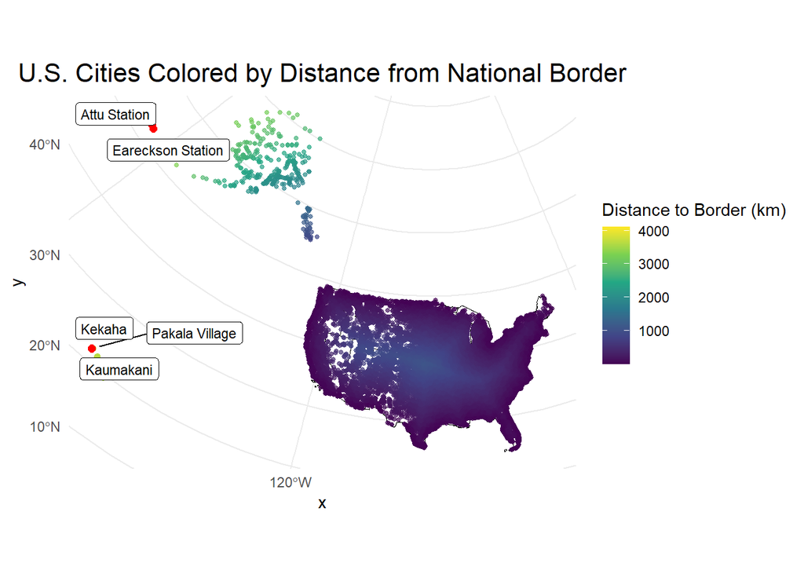

```r
#Identify the 5 cities farthest from the border:
farthest_5 <- cities_eqdc %>%
  arrange(desc(dist_to_border_km)) %>%
  slice(1:5) %>%
  mutate(
    coords = st_coordinates(geometry),
    x = coords[, 1],
    y = coords[, 2]
  )

# plot the new map
ggplot() +
  # Plot U.S. states
  geom_sf(data = states_eqdc, fill = "white", color = "black", lwd = 0.3) +

  # Plot all cities colored by distance to border
  geom_sf(data = cities_eqdc, aes(color = dist_to_border_km), size = 1, alpha = 0.7) +

  # Redraw and highlight the 5 farthest cities
  geom_sf(data = farthest_5, color = "red", size = 2) +

  # Label those cities
  geom_label_repel(
    data = farthest_5,
    aes(x = x, y = y, label = city),
    size = 3,
    box.padding = 0.3,
    point.padding = 0.5,
    segment.color = "black"
  ) +

  # Scale and theme
  scale_color_viridis_c(name = "Distance to Border (km)") +
  theme_minimal() +
  ggtitle("U.S. Cities Colored by Distance from National Border") +
  theme(plot.title = element_text(hjust = 0.5, size = 16))
```

# 3.3 City Distance from Nearest State

Create a map that colors USA cities by their distance from the nearest state border. In addition, re-draw and label the 5 cities that are farthest from any border.

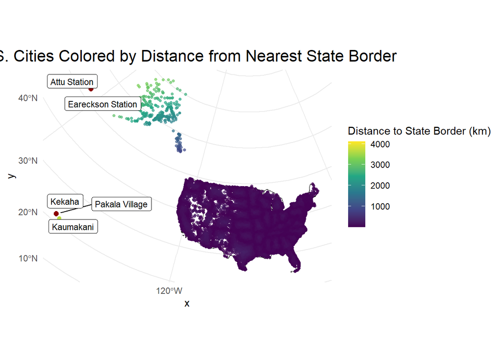

```r
# coloring U.S. cities by their distance to the nearest state border, not the national border. Color all cities by dist_to_state_km

#Identify the 5 cities farthest from any state border:
farthest_5_state <- cities_eqdc %>%
  arrange(desc(dist_to_state_km)) %>%
  slice(1:5) %>%
  mutate(
    coords = st_coordinates(geometry),
    x = coords[, 1],
    y = coords[, 2]
  )

#create map
ggplot() +
  # Plot U.S. state outlines
  geom_sf(data = states_eqdc, fill = "white", color = "black", lwd = 0.3) +

  # Plot all cities, colored by distance to state border
  geom_sf(data = cities_eqdc, aes(color = dist_to_state_km), size = 1, alpha = 0.7) +

  # Highlight the 5 farthest cities
  geom_sf(data = farthest_5_state, color = "darkred", size = 2) +

  # Label the 5 cities
  geom_label_repel(
    data = farthest_5_state,
    aes(x = x, y = y, label = city),
    size = 3,
    box.padding = 0.3,
    point.padding = 0.5,
    segment.color = "black"
  ) +

  # Color scale and theme
  scale_color_viridis_c(name = "Distance to State Border (km)") +
  theme_minimal() +
  ggtitle("U.S. Cities Colored by Distance from Nearest State Border") +
  theme(plot.title = element_text(hjust = 0.5, size = 16))
```

# 3.4 Equidistance boundary from Mexico and Canada

Here we provide a little more challenge. Use gghighlight to identify the cities that are equal distance from the Canadian AND Mexican border 100 km.

In addition, label the five (5) most populous cites in this zone.

Hint: (create a new variable that finds the absolute difference between the distance to Mexico and the distance to Canada)

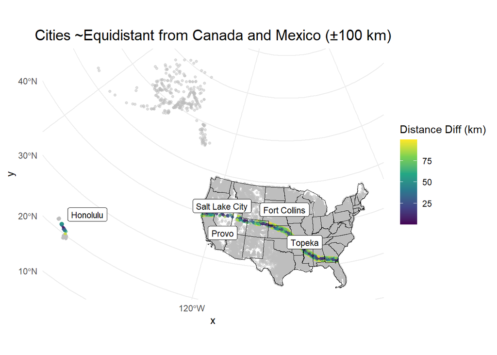

```r
# Create a new column for the absolute distance difference
cities_eqdc <- cities_eqdc %>%
  mutate(
    dist_diff_km = abs(dist_to_canada_km - dist_to_mexico_km)
  )


# Filter for cities within 100 km difference
equal_dist_cities <- cities_eqdc %>%
  filter(dist_diff_km <= 100)

# Get the 5 most populous cities in that zone
top5_equal_dist <- equal_dist_cities %>%
  arrange(desc(population)) %>%
  slice(1:5) %>%
  mutate(
    coords = st_coordinates(geometry),
    x = coords[,1],
    y = coords[,2]
  )

# Plot with ggplot2, geom_sf, and gghighlight.use gghighlight to emphasize only the cities in the equidistant zone:
ggplot(data = cities_eqdc) +
  # Plot all cities with low alpha
  geom_sf(aes(color = dist_diff_km), size = 1, alpha = 0.5) +

  # Highlight only cities within 100 km of equal distance
  gghighlight(dist_diff_km <= 100, use_direct_label = FALSE) +

  # State borders for context
  geom_sf(data = states_eqdc, fill = NA, color = "black", lwd = 0.3) +

  # Label the 5 most populous cities in the zone
  geom_label_repel(
    data = top5_equal_dist,
    aes(x = x, y = y, label = city),
    size = 3,
    box.padding = 0.3,
    point.padding = 0.5,
    segment.color = "black"
  ) +

  scale_color_viridis_c(name = "Distance Diff (km)") +
  ggtitle("Cities ~Equidistant from Canada and Mexico (±100 km)") +
  theme_minimal() +
  theme(plot.title = element_text(hjust = 0.5, size = 15))
```

```r
# map shows:
# Highlight only cities within ±100 km of equal distance to Mexico and Canada
#Label the 5 most populous of those cities
```

# Question 4: Real World Application

Recently, Federal Agencies have claimed basic constitutional rights protected by the Fourth Amendment (protecting Americans from random and arbitrary stops and searches) do not apply fully at our borders (see Portland). For example, federal authorities do not need a warrant or suspicion of wrongdoing to justify conducting what courts have called a “routine search,” such as searching luggage or a vehicle. Specifically, federal regulations give U.S. Customs and Border Protection (CBP) authority to operate within 100 miles of any U.S. “external boundary”. Further information can be found at this ACLU article.

# 4.1 Quantifing Border Zone

How many cities are in this 100 mile zone? (100 miles ~ 160 kilometers) How many people live in a city within 100 miles of the border? What percentage of the total population is in this zone? Does it match the ACLU estimate in the link above? Report this information as a table.

```r
# Filter cities within the 100-mile (160 km) border zone and adds new column name.
#Compute summary values
flextable(
  cities_eqdc %>%
    summarise(
      `Cities in 160 km Zone` = sum(dist_to_border_km <= 160, na.rm = TRUE),
      `Total Cities` = n(),
      `People in 160 km Zone` = sum(population[dist_to_border_km <= 160], na.rm = TRUE),
      `Total Population` = sum(population, na.rm = TRUE),
      `Percent in Border Zone` = round(`People in 160 km Zone` / `Total Population` * 100, 1)
    )
)
```

| Cities in 160 km Zone | Total Cities | People in 160 km Zone | Total Population | Percent in Border Zone | geometry |
| --- | --- | --- | --- | --- | --- |
| 9,813 | 30,973 | 216,043,045 | 398,421,566 | 54.2 | [[XY]] |

Around 54% of the population live 100 miles of the national border.

# 4.2 Mapping Border Zone

Make a map highlighting the cites within the 100 mile zone using gghighlight. Use a color gradient from ‘orange’ to ‘darkred’. Label the 10 most populous cities in the Danger Zone

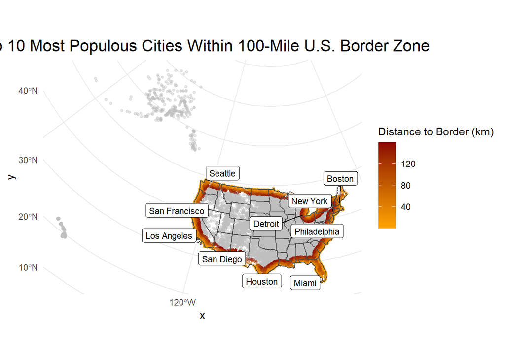

```r
top10_border_zone <- cities_eqdc %>%
  filter(dist_to_border_km <= 160) %>%
  arrange(desc(population)) %>%
  slice(1:10) %>%
  mutate(
    coords = st_coordinates(geometry),
    x = coords[,1],
    y = coords[,2]
  )


#make the map
ggplot(data = cities_eqdc) +
  # Plot cities with color based on distance to border
  geom_sf(aes(color = dist_to_border_km), size = 1, alpha = 0.4) +

  # Highlight only cities within 160 km of border
  gghighlight(dist_to_border_km <= 160, use_direct_label = FALSE) +

  # Redraw state boundaries on top
  geom_sf(data = states_eqdc, fill = NA, color = "gray30", lwd = 0.4) +

  # Label top 10 most populous cities in border zone
  geom_label_repel(
    data = top10_border_zone,
    aes(x = x, y = y, label = city),
    size = 3,
    box.padding = 0.3,
    point.padding = 0.5,
    segment.color = "black"
  ) +

  # Use color scale based on distance to border
  scale_color_gradient(low = "orange", high = "darkred", name = "Distance to Border (km)") +

  theme_minimal() +
  ggtitle("Top 10 Most Populous Cities Within 100-Mile U.S. Border Zone") +
  theme(plot.title = element_text(hjust = 0.5, size = 16))
```